# Coursera Assignment-PML

Helen-R

Monday, November 17, 2014

## A. Loading the dataset:

```r
url_tr <- "D:/Data Analysis/R/ML/Pj-dumbell/pml-training.csv"
url_te <- "D:/Data Analysis/R/ML/Pj-dumbell/pml-testing.csv"
tr <- read.csv(url_tr, fileEncoding = 'UTF-8')
te <- read.csv(url_te, fileEncoding = 'UTF-8')
```

The dumbbell lifting quality test is performed by 6 male participants between 20-28 year-old. [ref.1](http://groupware.les.inf.puc-rio.br/har)  
There are:  
- 19622 observations in the training set,  
- 20 sets for testing.

The outcome would be catagorized into 5 different types of exercise performance.  
Class A: exactly according to the speciﬁcation,  
Class B: throwing the elbows to the front,  
Class C: lifting the dumbbell only halfway,  
Class D: lowering the dumbbell only halfway,  
Class E: throwing the hips to the front.

### Tidy the dataset:

Among 160 variables:  
Variables 1~7 indicate the participants, time stamps, and activities (window, num) which can be ignored.

```
## [1] "X"                    "user_name"            "raw_timestamp_part_1"
## [4] "raw_timestamp_part_2" "cvtd_timestamp"       "new_window"
## [7] "num_window"
```

### Omit NAs and blanks: 52 features left, and column “classe”" is the outcome:

**Subsetting the data:** after exploring the data, it is decided to ignore columns of NA and blank, and column X (=row.index).  
1. locations: belt/arm/forearm/dumbbell  
2. Each location has 13 variables:  
- 3 variables from roll/pitch/yaw (Euler angle)  
- 3 variables from [gyro] x/y/z  
- 4 variables from [accel] x/y/z/total  
- 3 variables from [magnet] x/y/z

```r
train_raw <- tr[, c(8:11, 37:49, 60:68, 84:86, 102, 113:124, 140, 151:160)]
test_raw <- te[, c(8:11, 37:49, 60:68, 84:86, 102, 113:124, 140, 151:160)]
```

Therefore, 53 variables were selected instead of 160.

**Data slicing**: training vs. cross-validation is **“60:40”**

```r
set.seed(151)
inTrain <- createDataPartition(y=train_raw$classe, p = 0.6, list=F)
tr_set <- train_raw[inTrain,]
tr_cv <- train_raw[-inTrain,]
```

## B. Data training & cross-validation

```r
set.seed(234)
rFraw <- randomForest(tr_set[,-53], y = tr_set$classe, xtest=tr_cv[,-53], ytest=tr_cv$classe, ntree=1000, keep.forest=T)
```

### Show confusion matrix and error rate:

```
##
## Call:
##  randomForest(x = tr_set[, -53], y = tr_set$classe, xtest = tr_cv[,      -53], ytest = tr_cv$classe, ntree = 1000, keep.forest = T)
##                Type of random forest: classification
##                      Number of trees: 1000
## No. of variables tried at each split: 7
##
##         OOB estimate of  error rate: 0.64%
## Confusion matrix:
##      A    B    C    D    E class.error
## A 3346    2    0    0    0   0.0005974
## B   14 2257    8    0    0   0.0096534
## C    0   13 2034    7    0   0.0097371
## D    0    0   22 1907    1   0.0119171
## E    0    0    1    7 2157   0.0036952
##                 Test set error rate: 0.61%
## Confusion matrix:
##      A    B    C    D    E class.error
## A 2231    0    1    0    0    0.000448
## B    9 1504    5    0    0    0.009223
## C    0    4 1364    0    0    0.002924
## D    0    0   22 1262    2    0.018663
## E    0    0    2    3 1437    0.003467
```

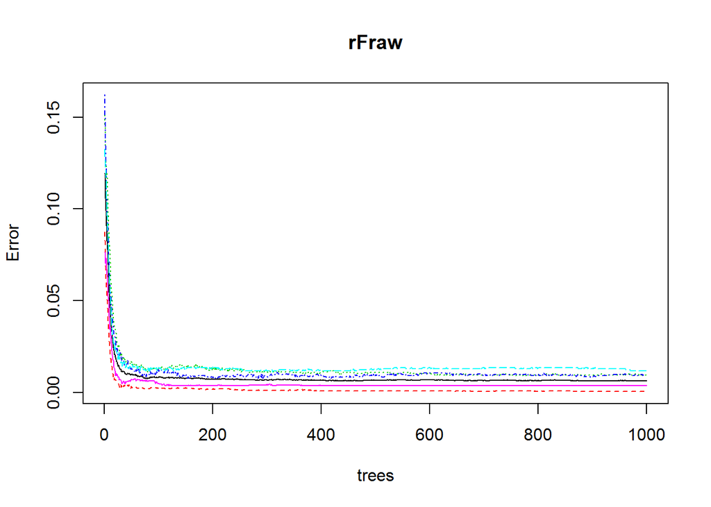

## C. Predicting

### According to the above random forest, the prediction to the test set is as follow:

```r
pred <- predict(rFraw, test_raw[,-53])
pred
```

```
##  1  2  3  4  5  6  7  8  9 10 11 12 13 14 15 16 17 18 19 20
##  B  A  B  A  A  E  D  B  A  A  B  C  B  A  E  E  A  B  B  B
## Levels: A B C D E
```